# Brain Stroke Prediction - ML Pipeline

Description & Utility

This ML pipeline predicts wether a client is at risk of having a stroke.

It is useful for hospitals to know whom may require more care. This pipeline could potentially save lives by alerting healthcare professionals to intervene and prevent any possible episodes.

I gathered my data from the following kaggle dataset: https://www.kaggle.com/datasets/zzettrkalpakbal/full-filled-brain-stroke-dataset

In this notebook, I will begin by loading then splitting the dataset to test and train. I will then plot a few chats to visualize the data. Furthermore, I will conduct Data Preprocessing and Feature engineering to prep for the predicition and handle imbalance by creating dummy variables. Afterwards, I will use two classification methods to classify the dataset and using the best method, I will finally predict the chances of having a brain stroke.

## 0) IMPORTING LIBRARIES & CREATING THE AGENDA

```python
## Step 1: Loading the Dataset
import pandas as pd

## Step 2: Splitting the Dataset
from sklearn.model_selection import train_test_split

## Step 3: Visualizing the Dataset
# Pie chart
import matplotlib.pyplot as plt
# Histogram -
# Scatter Plot
import seaborn as sns

## Step 4: Conducting Data Preprocessing and Feature Engineering
from sklearn.preprocessing import OneHotEncoder, StandardScaler
from sklearn.compose import make_column_transformer

## Step 5: Handling imbalanced Classes
from imblearn.over_sampling import SMOTE

## Step 6: Classification
from sklearn.tree import DecisionTreeClassifier
from sklearn.model_selection import GridSearchCV
from sklearn.svm import SVC

## Step 7: Testing the ML Pipeline
from sklearn.metrics import confusion_matrix
from sklearn.metrics import accuracy_score
from sklearn.metrics import precision_recall_fscore_support

## Step 8: Final Discussion & Insights -
```

## 1) LOADING THE DATASET

```python
# Read the csv file and loaded it into a pandas dataframe
df = pd.read_csv('Stroke_prediction_dataset.csv')
df.dropna(inplace=True)

df.head()
```

|  | gender | age | hypertension | heart_disease | ever_married | work_type | Residence_type | avg_glucose_level | bmi | smoking_status | stroke |
| --- | --- | --- | --- | --- | --- | --- | --- | --- | --- | --- | --- |
| 0 | Female | 61.0 | 0 | 0 | Yes | Self-employed | Rural | 202.21 | 31.555602 | never smoked | 1 |
| 1 | Female | 59.0 | 0 | 0 | Yes | Private | Rural | 76.15 | 30.242937 | Unknown | 1 |
| 2 | Male | 78.0 | 0 | 1 | Yes | Private | Urban | 219.84 | 30.698951 | Unknown | 1 |
| 3 | Male | 57.0 | 0 | 1 | No | Govt_job | Urban | 217.08 | 33.808410 | Unknown | 1 |
| 4 | Male | 58.0 | 0 | 0 | Yes | Private | Rural | 189.84 | 31.378534 | Unknown | 1 |

## 2) SPLITTING THE DATASET

I must split the dataset into training and test.

To do so, I used the train_test_split method found in the sklearn library. Automatically, the program splits the dataset into a 3:1 ratio, with approximately 75% allocated to the training set and the other 25% to the testing set.

```python
df.shape
```

```
(201, 11)
```

```python
#The dataset has 201 rows and 11 columns
```

```python
df_train, df_test = train_test_split(df)

print('Training set:', df_train.shape)
print('Test set:', df_test.shape)
```

```
Training set: (150, 11)
Test set: (51, 11)
```

## 3) VISUALIZING THE DATASET

To visualize the dataset, I must plot various charts:

- Using the matplotlib library I was able to plot pie chart and histograms for each column, for both categorical and numerical columns
- Using seaborn I was able to plot a scattered plot to visualize how the age column may effect the outcomes of the other numerical columns, such as heart disease.

However, before plotting charts, I decided to create two lists to seperate categorical and numerical columns.

After creating two empty lists, one for categorical and one for numerical, I set a for loop that goes through all given columns in the dataset, checks what type of data is stored in the column, and depending on the results, appends the column to its righteous list.

```python
cat = []
num = []

for col in df.columns:
    if df[col].dtype == 'object':
        cat.append(col)
    else:
        num.append(col)

print('Categorical columns: ', cat)
print('\nNumerical columns: ', num)
```

```
Categorical columns:  ['gender', 'ever_married', 'work_type', 'Residence_type', 'smoking_status']

Numerical columns:  ['age', 'hypertension', 'heart_disease', 'avg_glucose_level', 'bmi', 'stroke']
```

## Pie Chart - Categorical Columns

To create a pie chart for every categorical column in the dataset individually, I set a for loop to go through all the elements in the categorical list created above, and plot a pie chart for each one of them

- Using "figsize" i was able to manipulate the sizing of the charts.

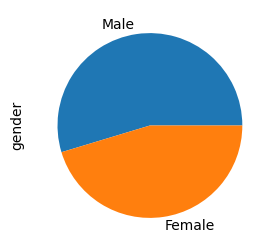

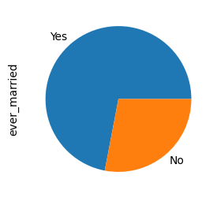

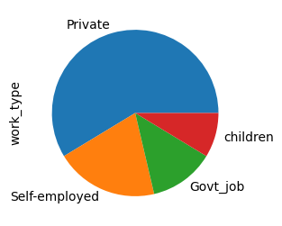

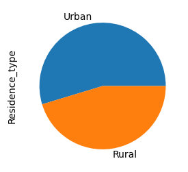

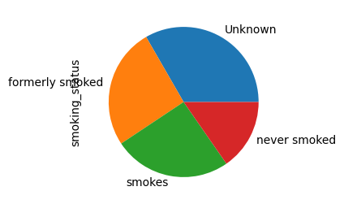

```python
for cat_element in cat:
    fig, ax = plt.subplots(figsize=(3, 3))
    df_train[cat_element].value_counts().plot(kind='pie')
    plt.show()
```

## Histogram - Numerical Columns

To create a histogram for every numerical column in the dataset individually, I set a for loop to go through all the elements in the numerical list created above, and plot a histogram for each one of them

- Using the "bins" i was able to manipulate the size of the bars in the charts.
- I also set each numerical value on the x-axis with the method "set_xlabel()"

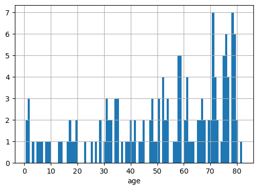

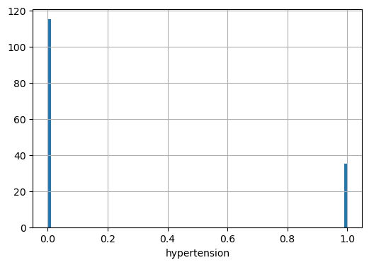

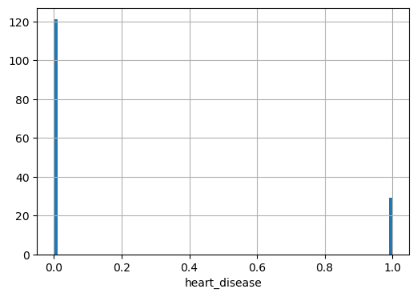

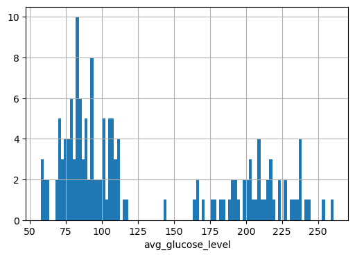

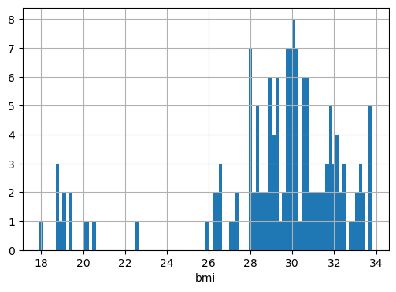

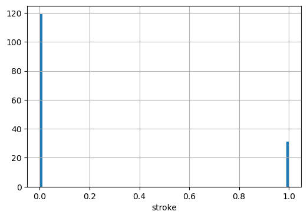

```python
for num_element in num:
    fig, ax = plt.subplots(figsize= (6, 4))
    hist_plot = df_train[num_element].hist(bins=100, ax= ax)
    hist_plot.set_xlabel(num_element)
```

## Scatter Plot

As mentioned, I decided to use a scatter plot to visualize the effect of age.

To do so for every numerical column, I created a for loop that will iterate len(num) amount of times, while starting at the second index to avoid the age column.

- Using matplot I manipulated the sizing of the charts.
- Using the seaborn library, I plotted the scattersplot while setting the age column on all x-axises of the itteration outputs.

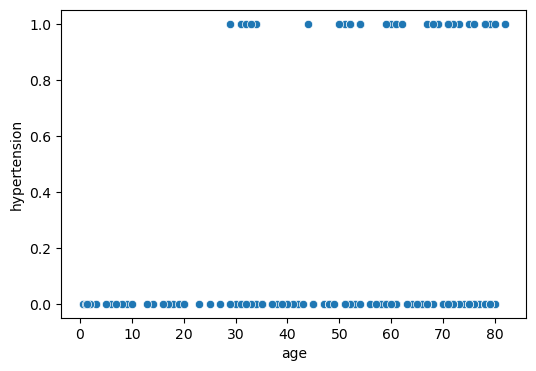

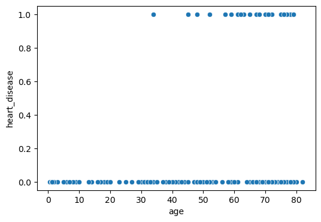

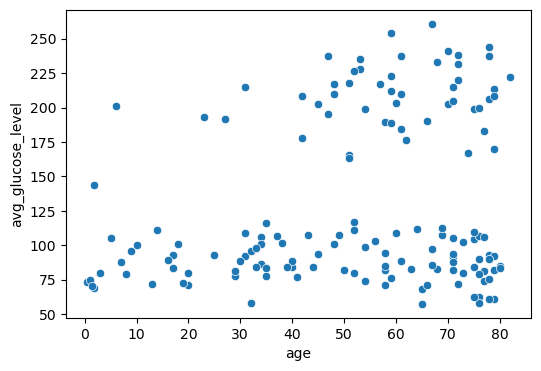

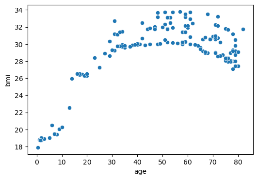

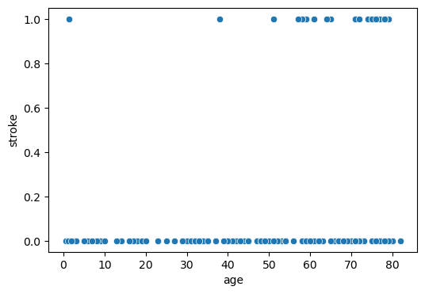

```python
for i in range(1, len(num)):
    plt.figure(figsize= (6, 4))
    sns.scatterplot (x= 'age', y= num[i], data= df_train)
```

## 4) CONDUCTING DATA PREPROCESSING & FEATURE ENGINEEING

```python
X_train, y_train = df_train.drop(columns= ['stroke']), df_train['stroke']
```

```python
X_train
```

|  | gender | age | hypertension | heart_disease | ever_married | work_type | Residence_type | avg_glucose_level | bmi | smoking_status |
| --- | --- | --- | --- | --- | --- | --- | --- | --- | --- | --- |
| 105 | Male | 0.48 | 0 | 0 | No | children | Urban | 73.02 | 17.899295 | Unknown |
| 87 | Male | 58.00 | 0 | 0 | Yes | Private | Urban | 94.00 | 30.272074 | Unknown |
| 91 | Male | 34.00 | 0 | 0 | Yes | Private | Rural | 86.51 | 29.904710 | formerly smoked |
| 103 | Female | 42.00 | 0 | 0 | Yes | Private | Urban | 208.06 | 32.497359 | smokes |
| 149 | Female | 68.00 | 0 | 0 | No | Private | Urban | 82.85 | 28.968394 | smokes |
| ... | ... | ... | ... | ... | ... | ... | ... | ... | ... | ... |
| 171 | Female | 79.00 | 0 | 0 | Yes | Private | Rural | 208.05 | 29.786945 | smokes |
| 37 | Female | 76.00 | 1 | 1 | Yes | Self-employed | Urban | 199.86 | 31.684031 | smokes |
| 138 | Male | 71.00 | 0 | 1 | Yes | Private | Urban | 204.98 | 30.976759 | formerly smoked |
| 120 | Male | 62.00 | 1 | 1 | Yes | Private | Rural | 176.25 | 32.438014 | never smoked |
| 148 | Male | 78.00 | 1 | 0 | Yes | Self-employed | Urban | 90.19 | 29.210834 | Unknown |

150 rows × 10 columns

```python
y_train
```

```
105    0
87     0
91     0
103    0
149    0
      ..
171    0
37     1
138    0
120    0
148    0
Name: stroke, Length: 150, dtype: int64
```

```python
X_test, y_test = df_test.drop(columns= ['stroke']), df_test['stroke']
```

```python
num.remove('stroke')
```

```python
onehot = OneHotEncoder(handle_unknown= 'ignore')
scaler = StandardScaler()

mct = make_column_transformer((onehot, cat), (scaler, num), remainder='passthrough')


X_train = mct.fit_transform(X_train)
X_test = mct.transform(X_test)
```

## 5) HANDLING IMBALANCED CLASSES

To train our ML pipeline, we balance all columns to have a 1:1 ratio by creating more instances.

Using the imbalanced-learn library we call the SMOTE method, and run the forseeing function to only the training sets, as it soly to increase precision and accuracy.

```python
smt = SMOTE()
X_train, y_train = smt.fit_resample(X_train, y_train)
```

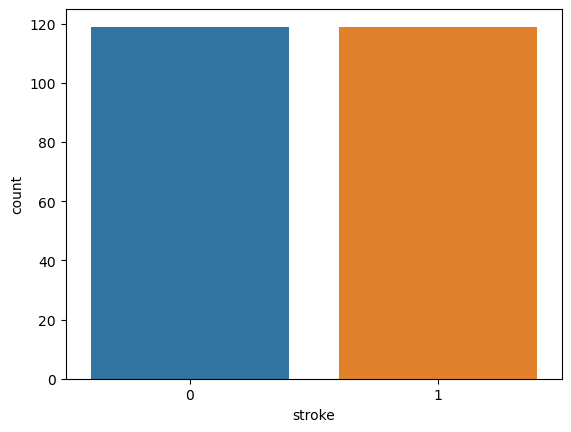

```python
# Plotting a bar chart to show equalization
sns.countplot(x=y_train)
```

## 6) CLASSIFICATION

### a) Decision Tree Classification

```python
parameters = {'criterion': ['gini'], 'splitter':['best'], 'max_depth': [3, 4, 5, 6, 10]}

dt = DecisionTreeClassifier()
clf_dt = GridSearchCV(dt,parameters, scoring='accuracy')

clf_dt.fit(X_train,y_train)

print('The best parameters for the Decision Tree Classification are: ', clf_dt.best_params_)
clf_dt.best_score_
```

```
The best parameters for the Decision Tree Classification are:  {'criterion': 'gini', 'max_depth': 5, 'splitter': 'best'}
```

```
0.836436170212766
```

### b) SVC

```python
parameters = {'C': [3, 5, 7], 'kernel':['linear'], 'gamma': ['scale', 'auto']}

svc = SVC()
clf_svc = GridSearchCV(svc,parameters, scoring='accuracy')

clf_svc.fit(X_train,y_train)

print('The best parameters for the Decision Tree Classification are: ', clf_svc.best_params_)
clf_svc.best_score_
```

```
The best parameters for the Decision Tree Classification are:  {'C': 3, 'gamma': 'scale', 'kernel': 'linear'}
```

```
0.714627659574468
```

## 7) TESTING THE ML PIPELINE

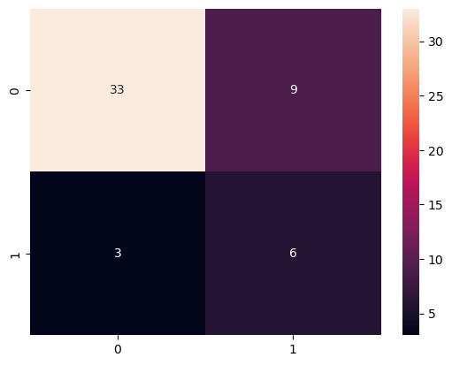

```python
dt_predict = clf_dt.predict(X_test)

cf_matrix_dt = confusion_matrix(y_test, dt_predict)
sns.heatmap(cf_matrix_dt, annot=True)
```

```python
accuracy_score(y_test, dt_predict)
```

```
0.7647058823529411
```

```python
precision_recall_fscore_support(y_test, dt_predict, zero_division= 1)
```

```
(array([0.91666667, 0.4       ]),
 array([0.78571429, 0.66666667]),
 array([0.84615385, 0.5       ]),
 array([42,  9], dtype=int64))
```

## 8) FINAL DISCUSSION & INSIGHTS

- Feature Importance:

As we can see, age plays a big role in increasing the stroke probabilities. The older a person is, the more likeley they are to have medical issues.

- Data Imbalance:

I used SMOTE to boost the proportion of minority samples in the dataset, which may enhance the model's performance.

- Model selection:

I did tested two Classification models: Decision Tree and SVC

Because decision tree is easier to read and can offer insights into the variables that are most crucial in forecasting possible strokes, I picked it over SVC.

In addition to handling non-linear relationships well, decision trees are less sensitive to outliers than SVC. Moreover, decision trees can accommodate a greater number of characteristics without overfitting and are less computationally expensive.

- Model performance:

Accuracy: The model's accuracy rating is 0.765, or 76.5%. This indicates that 76.5% of the samples in the test set were properly categorised by the model.

Recall: The model's recall score is [0.78571429, 0.66666667]. This indicates that the model's recall for the first class is 78.6% and for the second class is 66.7%. Recall quantifies the percentage of correct predictions made from all real positive samples.

F1-Score: The model has an F1-score of [0.84615385, 0.5]. This indicates that the model's F1-score for the first class is 84.6% and for the second class is 50%. When the classes are unbalanced, a reasonable statistic to employ is the F1-score, which is a weighted harmonic mean of precision and recall.

- Business impact:

I believe such ML pipelines are crucial for the healthcare industry. Investing in a precise and accurate pipeline that could predict potential health risks could evade life or death situations and save many lives.

# SUBMISSION FORM

[figure not shown]

```python
from IPython.display import Image

Image(filename='SubmissionForm_AIandML.jpg')
```